# Introduction to Open Data Science: Rstudio Exercise 5

# Tea and Human Development

## Introduction

This chapter has two distinct parts: in the first part, a Principal Component Analysis (PCA) of the combined data of the year 2015 [Human Development Index](http://hdr.undp.org/en/composite/HDI) (HDI) and [Gender Inequality Index](http://hdr.undp.org/en/composite/GII) (GII) of the United Nations is done. In the second part, a Multiple Correspondence Analysis (MDA) is done for the [“tea” dataset included in the FactoMineR R library](https://cran.r-project.org/web/packages/FactoMineR/FactoMineR.pdf).

## The Human Data

The combined HDI + GII data – henceforth referred to as the Human data – was prepared by joining the two datasets by country, calculating two additional values from the existing values, excluding variables that were deemed irrelevant for the analysis, and leaving off any records that were incomplete or that referred to geographic areas other than countries. (For the data wrangling script that was used to prepare the data, see [here](https://github.com/pinjaliina/IODS-project/blob/master/data/create_human.R)).

The data is read in as follows:

```r
# Read in the data
human <- as.data.frame(read.table('data/human.csv',  sep="\t", header=TRUE))
```

Glimpse the data to explore its structure and dimensions:

```r
# The data is only turned into an actual data frame at this point.
glimpse(human)
```

```
## Observations: 155
## Variables: 8
## $ se_f_of_m  <dbl> 1.0072389, 0.9968288, 0.9834369, 0.9886128, 0....
## $ lfp_f_of_m <dbl> 0.8908297, 0.8189415, 0.8251001, 0.8840361, 0....
## $ edu_exp    <dbl> 17.5, 20.2, 15.8, 18.7, 17.9, 16.5, 18.6, 16.5...
## $ life_exp   <dbl> 81.6, 82.4, 83.0, 80.2, 81.6, 80.9, 80.9, 79.1...
## $ gni_cap    <int> 64992, 42261, 56431, 44025, 45435, 43919, 3956...
## $ mmr        <int> 4, 6, 6, 5, 6, 7, 9, 28, 11, 8, 6, 4, 8, 4, 27...
## $ abr        <dbl> 7.8, 12.1, 1.9, 5.1, 6.2, 3.8, 8.2, 31.0, 14.5...
## $ mp_share   <dbl> 39.6, 30.5, 28.5, 38.0, 36.9, 36.9, 19.9, 19.4...
```

As seen from the output, the dataset has eight variables and includes data for 155 countries. The included variables may be described as follows:

- **se_f_of_m** = Share of female population with secondary education / Share of male population with secondary education
- **lfp_f_of_m** = Share of female population that participates in labour force / Share of male population that participates in labour force
- **edu_exp** = Expected years of education
- **life_exp** = Life expectancy at birth
- **gni_cap** = Gross national income (GNI) per capita (dollars, purchasing power parity)
- **mmr** = Maternal mortality rate
- **abr** = Adolescent birth rate
- **mp_share** = Share of female representatives in the national parliament

## Overview of the Human Data

A graphical overview of the Human data and summaries of its variables can be displayed as follows:

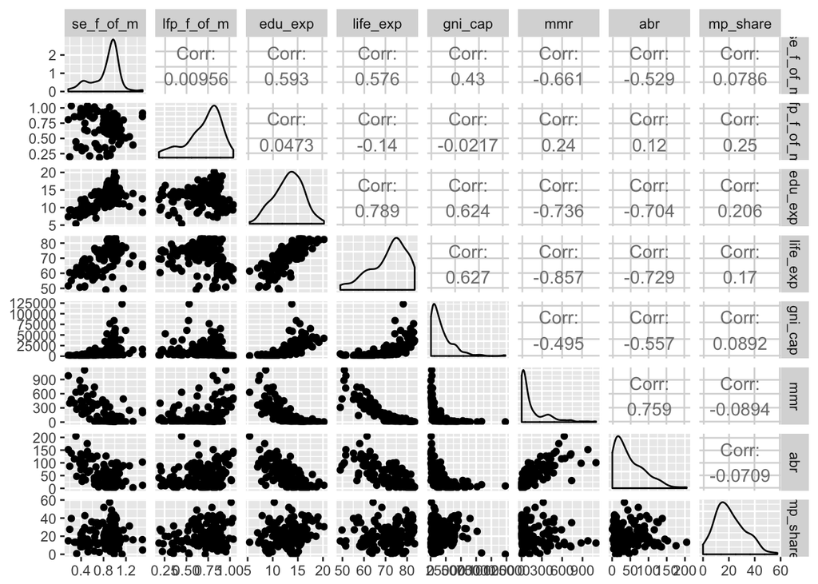

```r
ggpairs(human)
```

```r
summary(human)
```

```
##    se_f_of_m        lfp_f_of_m        edu_exp         life_exp
##  Min.   :0.1717   Min.   :0.1857   Min.   : 5.40   Min.   :49.00
##  1st Qu.:0.7264   1st Qu.:0.5984   1st Qu.:11.25   1st Qu.:66.30
##  Median :0.9375   Median :0.7535   Median :13.50   Median :74.20
##  Mean   :0.8529   Mean   :0.7074   Mean   :13.18   Mean   :71.65
##  3rd Qu.:0.9968   3rd Qu.:0.8535   3rd Qu.:15.20   3rd Qu.:77.25
##  Max.   :1.4967   Max.   :1.0380   Max.   :20.20   Max.   :83.50
##     gni_cap            mmr              abr            mp_share
##  Min.   :   581   Min.   :   1.0   Min.   :  0.60   Min.   : 0.00
##  1st Qu.:  4198   1st Qu.:  11.5   1st Qu.: 12.65   1st Qu.:12.40
##  Median : 12040   Median :  49.0   Median : 33.60   Median :19.30
##  Mean   : 17628   Mean   : 149.1   Mean   : 47.16   Mean   :20.91
##  3rd Qu.: 24512   3rd Qu.: 190.0   3rd Qu.: 71.95   3rd Qu.:27.95
##  Max.   :123124   Max.   :1100.0   Max.   :204.80   Max.   :57.50
```

As seen from the plots, the distribution of most of the variables is relatively skewed; the most notable exceptions are gender ratio of population with secondary education and expected years in education, which are reasonably close to the normal distribution. The min and max values and the scatter plots both show that some variables also have quite significant outliers, e.g. GNI per capita and maternal mortality rate.

The correlation figures also show that some variables correlate highly with each other. To spot such high correlation more easily, it’s useful to draw a correlation diagram:

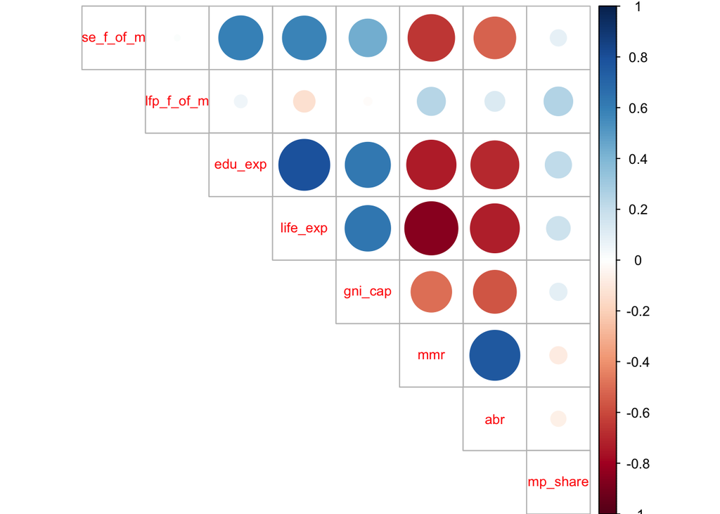

```r
corrplot(round(cor(human), digits = 2), method = "circle", type = "upper", tl.pos = "d", tl.cex = 0.8)
```

The plot demonstrates clearly that the strongest correlation of all is the strong negative correlation between life expectancy and maternal mortality rate; from the previous plot we can see that its value is -0.857. The next strongest correlations are the positive correlations between life expectancy and education expectancy (0.789) and maternal mortality rate and adolescent birth rate (0.759).

## PCA of the Human Data

To lower the dimensionality of the data, a principal component analysis (PCA) can be performed for it. This can be done, summarised and plotted as follows, using the singular value decomposition (SVD) method:

```r
pca_human <- prcomp(human)
s_human_nonstd <- summary(pca_human)
s_human_nonstd
```

```
## Importance of components:
##                              PC1      PC2   PC3   PC4   PC5   PC6
## Standard deviation     1.854e+04 185.5219 25.19 11.45 3.766 1.566
## Proportion of Variance 9.999e-01   0.0001  0.00  0.00 0.000 0.000
## Cumulative Proportion  9.999e-01   1.0000  1.00  1.00 1.000 1.000
##                           PC7    PC8
## Standard deviation     0.1912 0.1591
## Proportion of Variance 0.0000 0.0000
## Cumulative Proportion  1.0000 1.0000
```

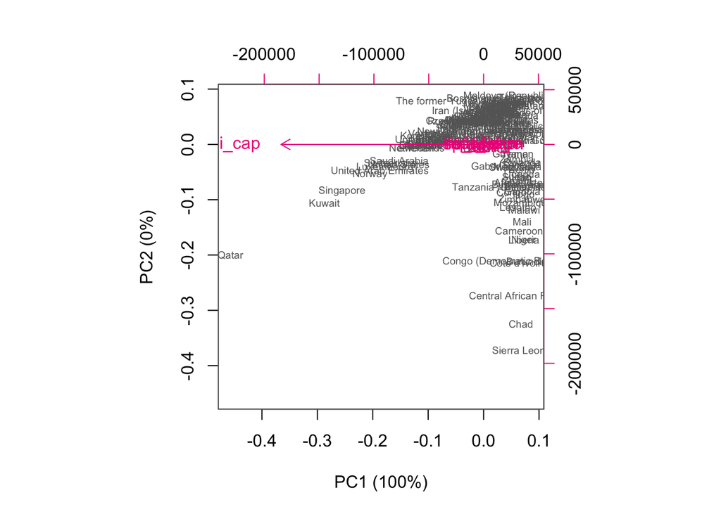

```r
# Percentages of variance for the plot titles.
pr_shns <- round(100*s_human_nonstd$importance[2, ], digits = 1)
pc_shns_lab <- paste0(names(pr_shns), " (", pr_shns, "%)")
biplot(pca_human, choices = 1:2, cex = c(0.6, 1), col = c("grey40", "deeppink2"), xlab = pc_shns_lab[1], ylab = pc_shns_lab[2])
```

```r
human_std <- scale(human) # Standardise the variables.
pca_human_std <- prcomp(human_std)
s_human_std <- summary(pca_human_std)
s_human_std
```

```
## Importance of components:
##                           PC1    PC2     PC3     PC4     PC5     PC6
## Standard deviation     2.0708 1.1397 0.87505 0.77886 0.66196 0.53631
## Proportion of Variance 0.5361 0.1624 0.09571 0.07583 0.05477 0.03595
## Cumulative Proportion  0.5361 0.6984 0.79413 0.86996 0.92473 0.96069
##                            PC7     PC8
## Standard deviation     0.45900 0.32224
## Proportion of Variance 0.02634 0.01298
## Cumulative Proportion  0.98702 1.00000
```

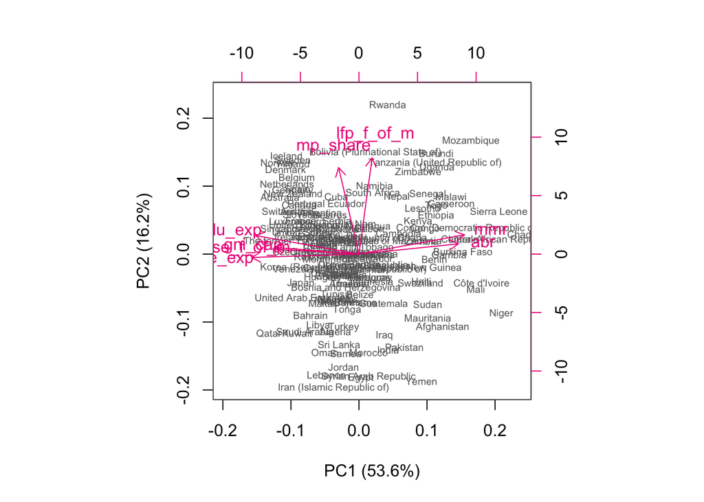

```r
# Percentages of variance for the plot titles.
pr_shs <- round(100*s_human_std$importance[2, ], digits = 1)
pc_shs_lab <- paste0(names(pr_shs), " (", pr_shs, "%)")
biplot(pca_human_std, choices = 1:2, cex = c(0.6, 1), col = c("grey40", "deeppink2"), xlab = pc_shs_lab[1], ylab = pc_shs_lab[2])
```

## Interpreting the PCA Results

The results now actually make sense, and as can be read from both the summary of the analysis and from the biplot of it, the first principal component explains 53.6% of the total variance of the original eight variables, and the second principal component explains 16.2% of it.

By inspecting the plot, we can see that the first principal component represents variables related mostly to poverty and the second principal components variables related mostly to equality, and that these two don’t correlate with other.

We can thus say that poverty explains most of the total variance in the data, but equality also explains some of it. From the plot arrows, we can see that high maternal mortality rate and adolescent birth rate correlate strongly with poverty and that high life expectancy, high educational expectancy, high ratio of females with secondary education and high GNI have a strong negative correlation with it. Further, we can see that high ratio of female MPs and high ratio of female participation in the labour force have strong positive correlation with equality, even though equality explains much less of the total variability in the data than poverty.

## And Now it’s Teatime!

As the final part of the Exercise 5, a Multiple Correspondence Analysis (MCA) was done for the [“tea” dataset included in the FactoMineR R library](https://cran.r-project.org/web/packages/FactoMineR/FactoMineR.pdf). The package description explains the data as follows: ”We asked to 300 individuals how they drink tea (18 questions), what are their product’s perception (12 questions) and some personal details (4 questions).”

Let’s load the data and look at the structure and dimensions of the dataset: Glimpse the data to explore its structure and dimensions:

```r
data("tea")
glimpse(tea)
```

```
## Observations: 300
## Variables: 36
## $ breakfast        <fctr> breakfast, breakfast, Not.breakfast, No...
## $ tea.time         <fctr> Not.tea time, Not.tea time, tea time, N...
## $ evening          <fctr> Not.evening, Not.evening, evening, Not....
## $ lunch            <fctr> Not.lunch, Not.lunch, Not.lunch, Not.lu...
## $ dinner           <fctr> Not.dinner, Not.dinner, dinner, dinner,...
## $ always           <fctr> Not.always, Not.always, Not.always, Not...
## $ home             <fctr> home, home, home, home, home, home, hom...
## $ work             <fctr> Not.work, Not.work, work, Not.work, Not...
## $ tearoom          <fctr> Not.tearoom, Not.tearoom, Not.tearoom, ...
## $ friends          <fctr> Not.friends, Not.friends, friends, Not....
## $ resto            <fctr> Not.resto, Not.resto, resto, Not.resto,...
## $ pub              <fctr> Not.pub, Not.pub, Not.pub, Not.pub, Not...
## $ Tea              <fctr> black, black, Earl Grey, Earl Grey, Ear...
```

[output cut: 23 more lines]

We can see that except for the age, all of the variables are categorial – many of them actually binary – and there are 36 of them in total. It’s difficult to visualise or analyse the whole of such a large dataset at once; I actually tried to call `ggpairs()` for the whole dataset once, but R simply failed to create the temporary image file required to display the plot. Thus, I’m subsetting the data – creating a new dataset called [chai](http://wals.info/chapter/138) in the process – and picking up variables that tell what kind of tea people drink, whether they’re drinking it on the evenings or not, and whether they’re drinking it with their friends or not:

```r
# Etymology note: ”tea” is of Fujian, ”chai” of Cantonese origin. They
# both mean the same. For details, see http://wals.info/chapter/138
chai <- dplyr::select(tea, one_of(c('Tea','How','sugar','how','evening','friends')))
# Rename some columns for clarity.
names(chai)[1] <- 'type'
names(chai)[2] <- 'extras'
names(chai)[4] <- 'packaging'
glimpse(chai)
```

```
## Observations: 300
## Variables: 6
## $ type      <fctr> black, black, Earl Grey, Earl Grey, Earl Grey,...
## $ extras    <fctr> alone, milk, alone, alone, alone, alone, alone...
## $ sugar     <fctr> sugar, No.sugar, No.sugar, sugar, No.sugar, No...
## $ packaging <fctr> tea bag, tea bag, tea bag, tea bag, tea bag, t...
## $ evening   <fctr> Not.evening, Not.evening, evening, Not.evening...
## $ friends   <fctr> Not.friends, Not.friends, friends, Not.friends...
```

It’s now more feasible to plot the remaining variables:

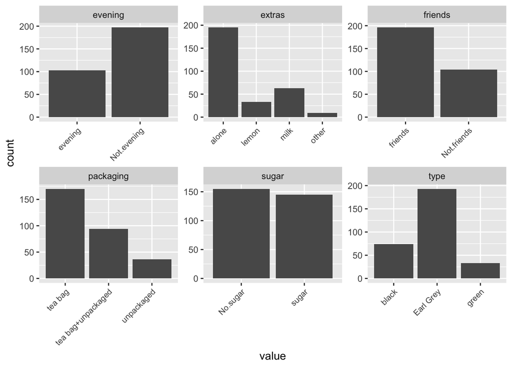

```r
ggplot(gather(chai), aes(value)) + facet_wrap("key", scales = "free") + geom_bar() + theme(axis.text.x = element_text(angle = 45, hjust = 1, size = 8))
```

Then, let’s do an MCA for the data and summarise the model:

```r
chai_mca <- MCA(chai, graph = FALSE)
summary(chai_mca)
```

```
##
## Call:
## MCA(X = chai, graph = FALSE)
##
##
## Eigenvalues
##                        Dim.1   Dim.2   Dim.3   Dim.4   Dim.5   Dim.6
## Variance               0.240   0.218   0.196   0.181   0.164   0.161
## % of var.             14.378  13.051  11.757  10.856   9.849   9.643
## Cumulative % of var.  14.378  27.429  39.185  50.041  59.890  69.533
##                        Dim.7   Dim.8   Dim.9  Dim.10
## Variance               0.150   0.131   0.128   0.099
## % of var.              8.974   7.871   7.652   5.970
## Cumulative % of var.  78.507  86.378  94.030 100.000
##
## Individuals (the 10 first)
##              Dim.1    ctr   cos2    Dim.2    ctr   cos2    Dim.3
## 1         |  0.553  0.426  0.235 | -0.309  0.146  0.073 |  0.149
## 2         |  0.936  1.218  0.481 | -0.238  0.087  0.031 |  0.587
## 3         | -0.291  0.117  0.097 |  0.124  0.024  0.018 | -0.214
## 4         |  0.122  0.021  0.017 | -0.720  0.794  0.583 | -0.090
## 5         |  0.141  0.027  0.018 | -0.163  0.041  0.024 | -0.280
## 6         |  0.466  0.302  0.250 | -0.410  0.258  0.194 | -0.133
## 7         |  0.035  0.002  0.002 | -0.123  0.023  0.024 | -0.067
## 8         |  0.611  0.519  0.182 |  0.009  0.000  0.000 |  0.439
## 9         |  0.370  0.191  0.083 | -0.204  0.064  0.025 |  0.343
## 10        |  0.437  0.266  0.109 |  0.693  0.735  0.274 | -0.046
##              ctr   cos2
## 1          0.038  0.017 |
## 2          0.586  0.189 |
## 3          0.078  0.053 |
## 4          0.014  0.009 |
## 5          0.134  0.072 |
## 6          0.030  0.020 |
## 7          0.008  0.007 |
## 8          0.328  0.094 |
## 9          0.201  0.072 |
## 10         0.004  0.001 |
##
## Categories (the 10 first)
```

[output cut: 16 more lines]

```
## lemon       1.666 |   0.213   0.423   0.006   1.292 |
## milk       -5.314 |   0.813  11.801   0.176   7.247 |
## other       4.910 |   3.582  32.731   0.397  10.891 |
## No.sugar    7.489 |  -0.055   0.134   0.003  -0.987 |
## sugar      -7.489 |   0.059   0.143   0.003   0.987 |
## tea bag   -11.550 |   0.162   1.271   0.034   3.211 |
##
## Categorical variables (eta2)
##             Dim.1 Dim.2 Dim.3
## type      | 0.391 0.241 0.279 |
## extras    | 0.176 0.164 0.668 |
## sugar     | 0.254 0.188 0.003 |
## packaging | 0.048 0.458 0.183 |
## evening   | 0.206 0.108 0.035 |
## friends   | 0.363 0.146 0.007 |
```

What can be seen from the output of the model summary is that none of the dimensions retain a large percentage of the total variance, and that there are no strong links between the dimensions and the categorical variables, even though some of the categories do have coordinate values significantly different from zero. Drawing a variable biplot of the analysis confirms our findings:

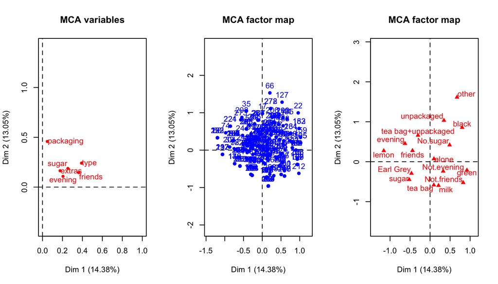

```r
par(mfrow = c(1,3)) # Set some graphical params.
plot(chai_mca, choix = "var", title = "MCA variables") # The variable biplot.
plot(chai_mca, choix = "ind", invisible = "var") # The individuals plot.
plot(chai_mca, choix = "ind", invisible = "ind") # The categories plot.
```

As can be seen from the plot on the left, none of the variables are very strongly linked to either of the dimensions. The strongest link is the packaging variable’s – i.e. whether the person prefers to drink loose tea, teabags or both – link to the second dimension. The rest of the links are quite weak.

The plots on the center and on the right represent the individuals and categories, respectively, and demonstrate that there is no clear pattern in either of them.